# Employment -Model Selection

21 November 2016

## Load Employee Data

longley <- read.table(file.choose(),header = TRUE)

```r
longley <- read.table(file.choose(),header = TRUE);
summary(longley)
```

```
##        x1               x2               x3             x4
##  Min.   : 83.00   Min.   :234289   Min.   :1870   Min.   :1456
##  1st Qu.: 94.53   1st Qu.:317881   1st Qu.:2348   1st Qu.:2298
##  Median :100.60   Median :381427   Median :3144   Median :2718
##  Mean   :101.68   Mean   :387698   Mean   :3193   Mean   :2607
##  3rd Qu.:111.25   3rd Qu.:454086   3rd Qu.:3842   3rd Qu.:3061
##  Max.   :116.90   Max.   :554894   Max.   :4806   Max.   :3594
##        x5               x6             y
##  Min.   :107608   Min.   :1947   Min.   :60171
##  1st Qu.:111789   1st Qu.:1951   1st Qu.:62713
##  Median :116804   Median :1954   Median :65504
##  Mean   :117424   Mean   :1954   Mean   :65317
##  3rd Qu.:122304   3rd Qu.:1958   3rd Qu.:68291
##  Max.   :130081   Max.   :1962   Max.   :70551
```

# Build full model with all the variables and the initial model with no variable

```r
model_0 <- lm(y~1,data = longley);
model_full <-lm(y~x1+x2+x3+x4+x5+x6,data = longley);
```

# Run the stepwise forward selection process to identify the best model

```r
step(model_0,scope = list(lower=model_0,upper=model_full),direction = "forward");
```

```
## Start:  AIC=262.21
## y ~ 1
##
##        Df Sum of Sq       RSS    AIC
## + x2    1 178972686   6036140 209.45
## + x6    1 174552297  10456529 218.24
## + x1    1 174397450  10611376 218.48
## + x5    1 170642900  14365926 223.32
## + x3    1  46715529 138293297 259.56
## + x4    1  38690907 146317919 260.46
## <none>              185008826 262.21
##
## Step:  AIC=209.45
## y ~ x2
##
##        Df Sum of Sq     RSS    AIC
## + x3    1   2457075 3579065 203.09
## + x5    1   2161779 3874361 204.36
## + x6    1   1125196 4910944 208.15
## <none>              6036140 209.45
## + x1    1    211945 5824195 210.88
## + x4    1     76652 5959488 211.25
##
## Step:  AIC=203.09
## y ~ x2 + x3
##
##        Df Sum of Sq     RSS    AIC
## + x4    1    822353 2756712 200.91
## <none>              3579065 203.09
## + x6    1    339797 3239268 203.49
## + x5    1     96823 3482242 204.65
## + x1    1     18841 3560224 205.00
##
## Step:  AIC=200.91
## y ~ x2 + x3 + x4
##
##        Df Sum of Sq     RSS    AIC
## + x6    1   1898031  858680 184.25
## + x5    1    390114 2366597 200.47
## <none>              2756712 200.91
## + x1    1     72885 2683827 202.48
##
## Step:  AIC=184.25
## y ~ x2 + x3 + x4 + x6
##
##        Df Sum of Sq    RSS    AIC
## <none>              858680 184.25
## + x5    1     19332 839348 185.88
## + x1    1     17507 841173 185.92
```

```
##
## Call:
## lm(formula = y ~ x2 + x3 + x4 + x6, data = longley)
##
## Coefficients:
## (Intercept)           x2           x3           x4           x6
##  -3.599e+06   -4.019e-02   -2.088e+00   -1.015e+00    1.887e+03
```

# Above model selection leads to model with X2,X3,X4 and X6

# Remove X5 from data set and analyse

```r
longley <-longley[,-5]
```

# Regressing X1+X2+X3+X4+X6 on y

```r
model <- lm(y~x1+x2+x3+x4+x6, data = longley);
summary(model)
```

```
##
## Call:
## lm(formula = y ~ x1 + x2 + x3 + x4 + x6, data = longley)
##
## Residuals:
##     Min      1Q  Median      3Q     Max
## -390.12 -143.42  -35.60   97.28  461.36
##
## Coefficients:
##               Estimate Std. Error t value Pr(>|t|)
## (Intercept) -3.565e+06  7.724e+05  -4.615 0.000957 ***
## x1           2.771e+01  6.075e+01   0.456 0.657984
## x2          -4.213e-02  1.762e-02  -2.391 0.037891 *
## x3          -2.104e+00  3.029e-01  -6.945 3.97e-05 ***
## x4          -1.042e+00  2.002e-01  -5.207 0.000397 ***
## x6           1.869e+03  3.994e+02   4.680 0.000867 ***
## ---
## Signif. codes:  0 '***' 0.001 '**' 0.01 '*' 0.05 '.' 0.1 ' ' 1
##
## Residual standard error: 290 on 10 degrees of freedom
## Multiple R-squared:  0.9955, Adjusted R-squared:  0.9932
## F-statistic: 437.9 on 5 and 10 DF,  p-value: 2.266e-11
```

# Checking Correlation between variables

```r
cor(longley)
```

```
##           x1        x2         x3         x4        x6         y
## x1 1.0000000 0.9915892  0.6206334  0.4647442 0.9911492 0.9708985
## x2 0.9915892 1.0000000  0.6042609  0.4464368 0.9952735 0.9835516
## x3 0.6206334 0.6042609  1.0000000 -0.1774206 0.6682566 0.5024981
## x4 0.4647442 0.4464368 -0.1774206  1.0000000 0.4172451 0.4573074
## x6 0.9911492 0.9952735  0.6682566  0.4172451 1.0000000 0.9713295
## y  0.9708985 0.9835516  0.5024981  0.4573074 0.9713295 1.0000000
```

# Above two analysis shows that X1 is insignificant. However there is evidence of collinearity based on the correlation matrix between x1 and x2/x6. Checking VIF for multicollinearity.

```r
library("car");
vif(model);
```

```
##         x1         x2         x3         x4         x6
##  76.641401 546.870494  14.289620   3.460846 644.626426
```

This is confirmed by the high VIF values of X1, X2 and X6 as above.

## Including Plots

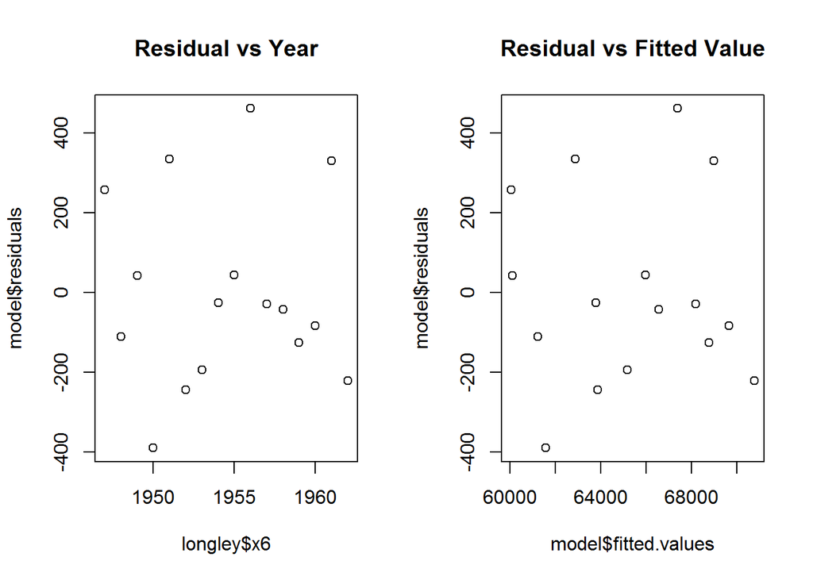

```r
par(mfrow=c(1,2))
plot(longley$x6,model$residuals,main="Residual vs Year")
plot(model$fitted.values,model$residuals,main="Residual vs Fitted Value")
```

Both the plots look similar and shows non-linear trend in X6(Year) and possible multi-collinearity.

# Possible solution to this could be transforming X6 and apply ridge regression to enforce penalty on variables.

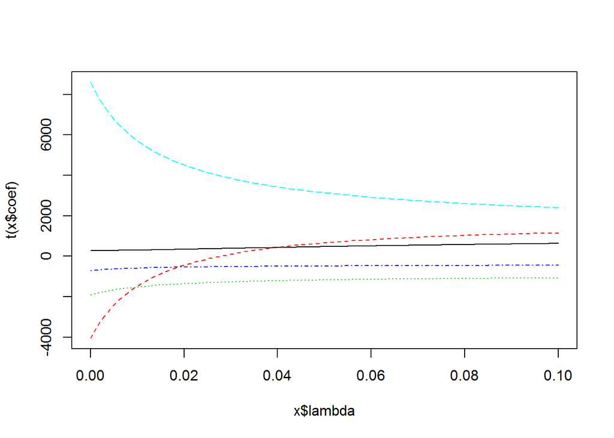

```r
library("MASS");
model_ridge<- lm.ridge(y~x1+x2+x3+x4+x6,data= longley, lambda = seq(0,0.1,0.001));
plot(model_ridge);
```

```r
select(model_ridge)
```

```
## modified HKB estimator is 0.00265978
## modified L-W estimator is 0.02192367
## smallest value of GCV  at 0.001
```

# We can check the fit of model by using qqplots stud resid vs quantiles

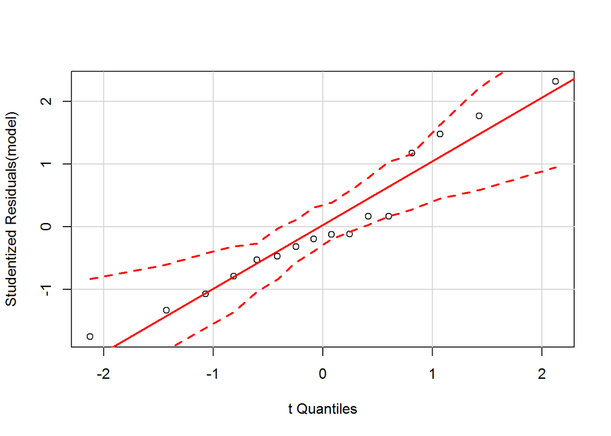

```r
par(mfrow=c(1,1))
qqPlot(model)
```

This shows that there are outliers, going out of confidence interval and plot does not show exact linear behaviour. Further model diagnostics can be applied to check outliers in data set, removing influential obs and add/remove variables to get better fit